# Projet 02 Analyste de donnees:

# Présenté par Fumbah Elvis

## INTRODUCTION

In this project, we analyzed WeRageDogs data to produce 03 useful information. WeRateDogs is a Twitter archive emailed to Udacity exclusively for learning.

This project involves collecting data through the tweeter API, processing the data and analyzing this dataset to produce useful insights into WeRageDogs Archive

We will fetch 03 datasets from 03 different sources: 02 of these datasets will be downloaded from the URL provided by Udacity, while the third dataset will be retrieved from the Tweeter Archive by querying their API .

## let visualise the twitter_achive_enhanced data set

### Problems Detected

In odre to be able to fetch the users dog's name, the text of the user have to begin with this is, and the next word will be the dogs name, meaning the dog can not have two names, text must be wrtten in enlish, and text must start with this is , by convention, equally, for the dog stage to be fetched, it must have to be spelled correctly and included in the text.

A visual assement of the Tweeter enhanced dataset will show alots of problems with the gotten dataset at the level of the dogs names and its stages.. some of these problems include:

### Problem 1

# The tweet with id 666049248165822465 Here we have a 1949 1st generation vulpix. has a wrong information on name field

# The text field coontains the dog name but it was not fetch correctly.

### Problem 2

the dog name of the tweet_id:( 889665388333682689 of text Here's a puppo that seems to be on the fence a...) has not been correctly fetch.

### Problem 3

# the tweet with id 885518971528720385 ( I have a new hero and his name is Howard. 14/1... ) has wrong information on name field

# the name is present but was not fetch

### Problem 4

the tweet with id 878604707211726852 (Martha is stunning how h*ckin dare you. 13/10 ... None.) also has wrong information on date name field but it was not fetch

### Problem 5

The tweet with id 858843525470990336 (I have stumbled puppon a doggo painting party.... ) has wrong information on name field but was not fetch correctly.

### Problem 6

the tweet with id 824325613288833024 (Retweet the h*ck out of this 13/10 pupper #Bel... ) has wrong information on the dog stage column and also on the name column.

### Problem 7

the tweet with id 841439858740625411 (Here we have some incredible doggos for #K9Vet... ) has wrong information on the dog stage column and also on the name column.

### Problem 8

the tweet with id 752568224206688256 (Here are three doggos completely misjudging an...) has wrong information on the stage of the dog because of a spelling error.

## analyse et visualisation des données

### we are going to analysis:

## 01- what is the proportion of dogs stages in these data set

## 02- which dog is widely owned by the population in these data set

## 03- Which dog type recieved the most favourites

### 01- what is the proportion of dogs stages in these data set

this question, we will have to find the count of each dog stage in the data set, devide by the total number of dogs in the data set and we will represent this better with a pie chart

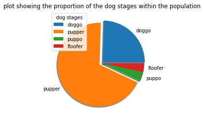

```python
plt.pie(dog_stage_dict.values(), labels=dog_stage_dict.keys(), explode = np.array(list(dog_stage_dict.values()))/1000, shadow=True)
plt.title('plot showing the proportion of the dog stages within the population')
plt.legend(title = "dog stages")
```

### which dog is largely owned by the population in these data set

the dog that is widely owned by the tweeters is the dog that appears most frequently in the the twweets, we can get this dog by grouping the dataset on the best best prediction( P1) and then getting the max value of the data set

```python
df2 = dogs_kinds[dogs_kinds['tweet_id']==139]
df2
```

| p1 | Unnamed: 0 | tweet_id | jpg_url | img_num | p1_conf | p1_dog | p2 | p2_conf | p2_dog | p3 | p3_conf | p3_dog | retweet_count | favorite_count | timestamp | source | text | rating_numerator | rating_denominator | name | doggo | floofer | pupper | puppo |
| --- | --- | --- | --- | --- | --- | --- | --- | --- | --- | --- | --- | --- | --- | --- | --- | --- | --- | --- | --- | --- | --- | --- | --- | --- |
| golden_retriever | 139 | 139 | 139 | 139 | 139 | 139 | 139 | 139 | 139 | 139 | 139 | 139 | 139 | 139 | 139 | 139 | 139 | 139 | 139 | 139 | 139 | 139 | 139 | 139 |

### This shows that the golden_retriever is widely distributed in the pupulation of the data set

### Which dog type recieved the most favourites

```python
we will get the dog stage with the highest favourite count

we need to group by dog type, then by favourite count
```

```python
df_max=df3[ df3['favorite_count'] == df3['favorite_count'].max() ]
df_max
```

| p1 | favorite_count |
| --- | --- |
| golden_retriever | 1447097 |

### golden_retriever recieved the most favourites of 1447097 counts in total

## conclutions

suject to this data set, it present quality, degree of cleaning and other restristrictions, the pupper dog stage is most distributed through out the pulation, and when it comes to the most favourite and most widely used dog, we have the golden_retriever.